# Analisis del Ranking Universitario Mundial

Gustavo Bruges. Ph.D.

El presente análisis se hizo con el fin didactico de mostrar como abordar el conjunto de datos para la evaluación final del Tópico Especial: R para Cientificos dictado en el Instituto Venezolano de Investigaciones Científicas. Existen distintos abordajes, y cada estudiante le dara su aproximación personal. Los datos fueron adquiridos del sitio https://data.world/

[figure not shown]

The Times Higher Education es una organización que seencarga de la clasificación universitaria mundial, genera tablas de rendimiento global que juzgan a las universidades en cuantoa a intensidad en la investigación en todas sus principales aspectos: enseñanza, investigación, transferencia de conocimientos y perspectivas internacionales. Utilizan 13 indicadores de desempeño cuidadosamente calibrados para proporcionar las comparaciones más completas y equilibradas

Los indicadores de desempeño se agrupan en cinco áreas:

-La enseñanza (el entorno de aprendizaje)

-Investigación (volumen, ingresos y reputación)

-Citas (influencia de la investigación)

-Perspectiva internacional (personal, estudiantes e investigación)

-Ingresos de la industria (transferencia de conocimiento

## Cargar paquetes necesarios

```r
rm(list = ls())
library(dplyr) # Manejo de data frames
library(tidyr) #Arreglo de tablas
library(readr) #Lectura de fuentes externas tipoc csv, retornara un objeto data.frame tibble
library(ggplot2) #Gramatica de graficos
library(GGally) #Analisis de correlacion de datos, similar a psych
library(ggthemes) #Temas adicionales para ggplot
library(gganimate) #Animacion de graficos hechos en ggplot
```

## Lectura de los datos

```r
worldUni <- read_csv("world-university-rankings-timesData.csv")
```

[output not shown]

#### Evaluacion de la data frame

```r
class(worldUni)
```

```
[1] "tbl_df"     "tbl"        "data.frame"
```

#### Evaluar los tipos de variables con glimpse

```r
glimpse(worldUni)
```

```
Observations: 2,603
Variables: 14
$ world_rank             <chr> "276-300", "350-400", "351-400", "251-275",...
$ university_name        <chr> "University of Iceland", "Yuan Ze Universit...
$ country                <chr> "Iceland", "Taiwan", "Thailand", "Iceland",...
$ teaching               <dbl> 10.7, 10.8, 11.3, 11.4, 11.6, 12.2, 12.2, 1...
$ international          <dbl> 56.9, 12.8, 23.8, 59.9, 18.9, 76.5, 14.3, 5...
$ research               <dbl> 17.3, 9.6, 10.2, 28.0, 10.4, 7.7, 22.6, 9.3...
$ citations              <dbl> 62.4, 58.3, 68.4, 71.0, 23.3, 55.5, 10.9, 4...
$ income                 <chr> "75.4", "29.2", "60.2", "74.4", "-", "27.1"...
$ total_score            <chr> "-", "-", "-", "-", "-", "-", "-", "-", "-"...
$ num_students           <dbl> 1396, 8663, 17791, 1396, 29594, 19665, 3792...
$ student_staff_ratio    <dbl> 25.9, 20.6, 23.7, 25.9, 32.3, 19.4, 162.6, ...
$ international_students <chr> "8%", "4%", "1%", "8%", "5%", "27%", "1%", ...
$ female_male_ratio      <chr> "66 : 34", "43 : 57", "42 : 58", "66 : 34",...
$ year                   <int> 2012, 2012, 2013, 2013, 2016, 2012, 2016, 2...
```

Observando las columnas y los tipos de datos, vemos que hay una serie de detalles que es importante corregir: world_rank: esta como tipo caracter, esto posiblemente a que en en el ranking a muchas universidades se le asigno un valor por intervalo y no un valor unico, en este sentido se tienen dos aproximaciones: 1) Hacer una coercion numerica o dividir los datos en dos grupos, el de aquellas univeridades que tienen un valor unico(una cifra) y las que posean intervalos y con estas ultimas tratar de estimar un ranking promedio entre los dos valores del intervalo. En este caso procederemos con la segunda aproximacion para ai tener una mayor numero de universidades

country_name: viene como caracter, se recomienda hacer una coercion a factor para posteriores analisis

income(ingresos) y total_score vienen como tipo caracter, en este caso debido a falta de informacion (hay guiones); si se realiza una coercion a numerico puede solventarse este asunto.

la columna international_students tiene asociado cada valor una etiqueta llamada porcentaje, el cual se puede modificar eliminando este caracter

la columna fema_male_ratio contiene un caracter : el cual lo podemos elimiar para tener un valor númerico con esta relacion

#### Modificacion de world_rank

```r
#separamos world_rank en dos columnas y calculamos una media entre ellas,
# utilizamos separate y transmute
worldUni <- worldUni %>%
  separate(world_rank,into=c("world_rank1","world_rank2"),convert=TRUE) %>%
  mutate(world_rank=round(rowMeans(.[1:2],na.rm=TRUE)))
```

```
Too few values at 1201 locations: 62, 95, 307, 339, 362, 384, 446, 496, 516, 517, 537, 550, 553, 595, 663, 671, 672, 677, 686, 687, ...
```

- Se separó world_rank en dos columnas world_rank1 y world_rank2 luego se creo nuevamente una columna world_rank con el promedio entre los dos etremos del intervalo, considerando los NA, ya que aquellas columnas con valores unicos carecen de un intervalo.

```r
glimpse(worldUni)
```

```
Observations: 2,603
Variables: 16
$ world_rank1            <int> 276, 350, 351, 251, 601, 301, 601, 350, 601...
$ world_rank2            <int> 300, 400, 400, 275, 800, 350, 800, 400, 800...
$ university_name        <chr> "University of Iceland", "Yuan Ze Universit...
$ country                <chr> "Iceland", "Taiwan", "Thailand", "Iceland",...
$ teaching               <dbl> 10.7, 10.8, 11.3, 11.4, 11.6, 12.2, 12.2, 1...
$ international          <dbl> 56.9, 12.8, 23.8, 59.9, 18.9, 76.5, 14.3, 5...
$ research               <dbl> 17.3, 9.6, 10.2, 28.0, 10.4, 7.7, 22.6, 9.3...
$ citations              <dbl> 62.4, 58.3, 68.4, 71.0, 23.3, 55.5, 10.9, 4...
$ income                 <chr> "75.4", "29.2", "60.2", "74.4", "-", "27.1"...
$ total_score            <chr> "-", "-", "-", "-", "-", "-", "-", "-", "-"...
$ num_students           <dbl> 1396, 8663, 17791, 1396, 29594, 19665, 3792...
$ student_staff_ratio    <dbl> 25.9, 20.6, 23.7, 25.9, 32.3, 19.4, 162.6, ...
$ international_students <chr> "8%", "4%", "1%", "8%", "5%", "27%", "1%", ...
$ female_male_ratio      <chr> "66 : 34", "43 : 57", "42 : 58", "66 : 34",...
$ year                   <int> 2012, 2012, 2013, 2013, 2016, 2012, 2016, 2...
$ world_rank             <dbl> 288, 375, 376, 263, 700, 326, 700, 375, 700...
```

Eliminamos las dos primeras columnas y colocamos world_rank como la primera

```r
worldUni <- worldUni[-c(1,2)]
glimpse(worldUni)
```

```
Observations: 2,603
Variables: 14
$ university_name        <chr> "University of Iceland", "Yuan Ze Universit...
$ country                <chr> "Iceland", "Taiwan", "Thailand", "Iceland",...
$ teaching               <dbl> 10.7, 10.8, 11.3, 11.4, 11.6, 12.2, 12.2, 1...
$ international          <dbl> 56.9, 12.8, 23.8, 59.9, 18.9, 76.5, 14.3, 5...
$ research               <dbl> 17.3, 9.6, 10.2, 28.0, 10.4, 7.7, 22.6, 9.3...
$ citations              <dbl> 62.4, 58.3, 68.4, 71.0, 23.3, 55.5, 10.9, 4...
$ income                 <chr> "75.4", "29.2", "60.2", "74.4", "-", "27.1"...
$ total_score            <chr> "-", "-", "-", "-", "-", "-", "-", "-", "-"...
$ num_students           <dbl> 1396, 8663, 17791, 1396, 29594, 19665, 3792...
$ student_staff_ratio    <dbl> 25.9, 20.6, 23.7, 25.9, 32.3, 19.4, 162.6, ...
$ international_students <chr> "8%", "4%", "1%", "8%", "5%", "27%", "1%", ...
$ female_male_ratio      <chr> "66 : 34", "43 : 57", "42 : 58", "66 : 34",...
$ year                   <int> 2012, 2012, 2013, 2013, 2016, 2012, 2016, 2...
$ world_rank             <dbl> 288, 375, 376, 263, 700, 326, 700, 375, 700...
```

```r
worldUni <- worldUni[,c(14,1:13)]
glimpse(worldUni)
```

```
Observations: 2,603
Variables: 14
$ world_rank             <dbl> 288, 375, 376, 263, 700, 326, 700, 375, 700...
$ university_name        <chr> "University of Iceland", "Yuan Ze Universit...
$ country                <chr> "Iceland", "Taiwan", "Thailand", "Iceland",...
$ teaching               <dbl> 10.7, 10.8, 11.3, 11.4, 11.6, 12.2, 12.2, 1...
$ international          <dbl> 56.9, 12.8, 23.8, 59.9, 18.9, 76.5, 14.3, 5...
$ research               <dbl> 17.3, 9.6, 10.2, 28.0, 10.4, 7.7, 22.6, 9.3...
$ citations              <dbl> 62.4, 58.3, 68.4, 71.0, 23.3, 55.5, 10.9, 4...
$ income                 <chr> "75.4", "29.2", "60.2", "74.4", "-", "27.1"...
$ total_score            <chr> "-", "-", "-", "-", "-", "-", "-", "-", "-"...
$ num_students           <dbl> 1396, 8663, 17791, 1396, 29594, 19665, 3792...
$ student_staff_ratio    <dbl> 25.9, 20.6, 23.7, 25.9, 32.3, 19.4, 162.6, ...
$ international_students <chr> "8%", "4%", "1%", "8%", "5%", "27%", "1%", ...
$ female_male_ratio      <chr> "66 : 34", "43 : 57", "42 : 58", "66 : 34",...
$ year                   <int> 2012, 2012, 2013, 2013, 2016, 2012, 2016, 2...
```

Procedemos a realiar la coercion de las columnas country(factor), income, total_score

```r
worldUni <- worldUni %>%
  mutate(world_rank=as.integer(world_rank),country=factor(country),income=as.numeric(income),
         total_score=as.numeric(total_score))
```

```
NAs introduced by coercionNAs introduced by coercion
```

```r
glimpse(worldUni)
```

```
Observations: 2,603
Variables: 14
$ world_rank             <int> 288, 375, 376, 263, 700, 326, 700, 375, 700...
$ university_name        <chr> "University of Iceland", "Yuan Ze Universit...
$ country                <fctr> Iceland, Taiwan, Thailand, Iceland, United...
$ teaching               <dbl> 10.7, 10.8, 11.3, 11.4, 11.6, 12.2, 12.2, 1...
$ international          <dbl> 56.9, 12.8, 23.8, 59.9, 18.9, 76.5, 14.3, 5...
$ research               <dbl> 17.3, 9.6, 10.2, 28.0, 10.4, 7.7, 22.6, 9.3...
$ citations              <dbl> 62.4, 58.3, 68.4, 71.0, 23.3, 55.5, 10.9, 4...
$ income                 <dbl> 75.4, 29.2, 60.2, 74.4, NA, 27.1, 100.0, 26...
$ total_score            <dbl> NA, NA, NA, NA, NA, NA, NA, NA, NA, NA, NA,...
$ num_students           <dbl> 1396, 8663, 17791, 1396, 29594, 19665, 3792...
$ student_staff_ratio    <dbl> 25.9, 20.6, 23.7, 25.9, 32.3, 19.4, 162.6, ...
$ international_students <chr> "8%", "4%", "1%", "8%", "5%", "27%", "1%", ...
$ female_male_ratio      <chr> "66 : 34", "43 : 57", "42 : 58", "66 : 34",...
$ year                   <int> 2012, 2012, 2013, 2013, 2016, 2012, 2016, 2...
```

Ahora procedemos a eliminar el porcentaje de international_students con la funcion parse_number de readr

```r
worldUni <- worldUni %>% mutate(international_students=parse_number(international_students))
glimpse(worldUni)
```

```
Observations: 2,603
Variables: 14
$ world_rank             <int> 288, 375, 376, 263, 700, 326, 700, 375, 700...
$ university_name        <chr> "University of Iceland", "Yuan Ze Universit...
$ country                <fctr> Iceland, Taiwan, Thailand, Iceland, United...
$ teaching               <dbl> 10.7, 10.8, 11.3, 11.4, 11.6, 12.2, 12.2, 1...
$ international          <dbl> 56.9, 12.8, 23.8, 59.9, 18.9, 76.5, 14.3, 5...
$ research               <dbl> 17.3, 9.6, 10.2, 28.0, 10.4, 7.7, 22.6, 9.3...
$ citations              <dbl> 62.4, 58.3, 68.4, 71.0, 23.3, 55.5, 10.9, 4...
$ income                 <dbl> 75.4, 29.2, 60.2, 74.4, NA, 27.1, 100.0, 26...
$ total_score            <dbl> NA, NA, NA, NA, NA, NA, NA, NA, NA, NA, NA,...
$ num_students           <dbl> 1396, 8663, 17791, 1396, 29594, 19665, 3792...
$ student_staff_ratio    <dbl> 25.9, 20.6, 23.7, 25.9, 32.3, 19.4, 162.6, ...
$ international_students <dbl> 8, 4, 1, 8, 5, 27, 1, 13, 82, 8, 5, 23, 10,...
$ female_male_ratio      <chr> "66 : 34", "43 : 57", "42 : 58", "66 : 34",...
$ year                   <int> 2012, 2012, 2013, 2013, 2016, 2012, 2016, 2...
```

Para la columna female_male_ratio procedemos a realizar la separación del primer y el segundo termino de female:male. No se requiere usar mutate para generar las nuevas columnas

```r
 worldUni <- worldUni %>%
  separate(female_male_ratio,into=c("female","male"),sep=" : ", convert=TRUE)
```

```
Too few values at 3 locations: 26, 374, 707
```

```r
glimpse(worldUni)
```

```
Observations: 2,603
Variables: 15
$ world_rank             <int> 288, 375, 376, 263, 700, 326, 700, 375, 700...
$ university_name        <chr> "University of Iceland", "Yuan Ze Universit...
$ country                <fctr> Iceland, Taiwan, Thailand, Iceland, United...
$ teaching               <dbl> 10.7, 10.8, 11.3, 11.4, 11.6, 12.2, 12.2, 1...
$ international          <dbl> 56.9, 12.8, 23.8, 59.9, 18.9, 76.5, 14.3, 5...
$ research               <dbl> 17.3, 9.6, 10.2, 28.0, 10.4, 7.7, 22.6, 9.3...
$ citations              <dbl> 62.4, 58.3, 68.4, 71.0, 23.3, 55.5, 10.9, 4...
$ income                 <dbl> 75.4, 29.2, 60.2, 74.4, NA, 27.1, 100.0, 26...
$ total_score            <dbl> NA, NA, NA, NA, NA, NA, NA, NA, NA, NA, NA,...
$ num_students           <dbl> 1396, 8663, 17791, 1396, 29594, 19665, 3792...
$ student_staff_ratio    <dbl> 25.9, 20.6, 23.7, 25.9, 32.3, 19.4, 162.6, ...
$ international_students <dbl> 8, 4, 1, 8, 5, 27, 1, 13, 82, 8, 5, 23, 10,...
$ female                 <chr> "66", "43", "42", "66", "58", "54", "78", "...
$ male                   <int> 34, 57, 58, 34, 42, 46, 22, 48, 52, 34, 70,...
$ year                   <int> 2012, 2012, 2013, 2013, 2016, 2012, 2016, 2...
```

```r
worldUni <- worldUni %>% mutate(female=as.numeric(female))
```

```
NAs introduced by coercion
```

Creamos nuevamente la columna female_male_ratio

```r
 worldUni <- worldUni %>% mutate(female_male_ratio=female/male)
glimpse(worldUni)
```

```
Observations: 2,603
Variables: 16
$ world_rank             <int> 288, 375, 376, 263, 700, 326, 700, 375, 700...
$ university_name        <chr> "University of Iceland", "Yuan Ze Universit...
$ country                <fctr> Iceland, Taiwan, Thailand, Iceland, United...
$ teaching               <dbl> 10.7, 10.8, 11.3, 11.4, 11.6, 12.2, 12.2, 1...
$ international          <dbl> 56.9, 12.8, 23.8, 59.9, 18.9, 76.5, 14.3, 5...
$ research               <dbl> 17.3, 9.6, 10.2, 28.0, 10.4, 7.7, 22.6, 9.3...
$ citations              <dbl> 62.4, 58.3, 68.4, 71.0, 23.3, 55.5, 10.9, 4...
$ income                 <dbl> 75.4, 29.2, 60.2, 74.4, NA, 27.1, 100.0, 26...
$ total_score            <dbl> NA, NA, NA, NA, NA, NA, NA, NA, NA, NA, NA,...
$ num_students           <dbl> 1396, 8663, 17791, 1396, 29594, 19665, 3792...
$ student_staff_ratio    <dbl> 25.9, 20.6, 23.7, 25.9, 32.3, 19.4, 162.6, ...
$ international_students <dbl> 8, 4, 1, 8, 5, 27, 1, 13, 82, 8, 5, 23, 10,...
$ female                 <dbl> 66, 43, 42, 66, 58, 54, 78, 52, 48, 66, 30,...
$ male                   <int> 34, 57, 58, 34, 42, 46, 22, 48, 52, 34, 70,...
$ year                   <int> 2012, 2012, 2013, 2013, 2016, 2012, 2016, 2...
$ female_male_ratio      <dbl> 1.9411765, 0.7543860, 0.7241379, 1.9411765,...
```

Eliminamos las columnas female y male

```r
worldUni <- worldUni[,-c(13,14)]
```

Ya tenemos nuestra tabla ajustada para el analisis

```r
glimpse(worldUni)
```

```
Observations: 2,603
Variables: 14
$ world_rank             <int> 288, 375, 376, 263, 700, 326, 700, 375, 700...
$ university_name        <chr> "University of Iceland", "Yuan Ze Universit...
$ country                <fctr> Iceland, Taiwan, Thailand, Iceland, United...
$ teaching               <dbl> 10.7, 10.8, 11.3, 11.4, 11.6, 12.2, 12.2, 1...
$ international          <dbl> 56.9, 12.8, 23.8, 59.9, 18.9, 76.5, 14.3, 5...
$ research               <dbl> 17.3, 9.6, 10.2, 28.0, 10.4, 7.7, 22.6, 9.3...
$ citations              <dbl> 62.4, 58.3, 68.4, 71.0, 23.3, 55.5, 10.9, 4...
$ income                 <dbl> 75.4, 29.2, 60.2, 74.4, NA, 27.1, 100.0, 26...
$ total_score            <dbl> NA, NA, NA, NA, NA, NA, NA, NA, NA, NA, NA,...
$ num_students           <dbl> 1396, 8663, 17791, 1396, 29594, 19665, 3792...
$ student_staff_ratio    <dbl> 25.9, 20.6, 23.7, 25.9, 32.3, 19.4, 162.6, ...
$ international_students <dbl> 8, 4, 1, 8, 5, 27, 1, 13, 82, 8, 5, 23, 10,...
$ year                   <int> 2012, 2012, 2013, 2013, 2016, 2012, 2016, 2...
$ female_male_ratio      <dbl> 1.9411765, 0.7543860, 0.7241379, 1.9411765,...
```

## ¿Qué países están representados?

## ¿Cuál es el país con más universidades en el ranking?

```r
tablaA <- prop.table(table(worldUni$country))
tablaA
```

```
                Argentina                 Australia                   Austria
             0.0003841721              0.0449481368              0.0119093354
               Bangladesh                   Belarus                   Belgium
             0.0003841721              0.0003841721              0.0142143680
                   Brazil                    Canada                     Chile
             0.0096043027              0.0414905878              0.0030733769
                    China                  Colombia                    Cyprus
             0.0318862851              0.0019208605              0.0003841721
           Czech Republic                   Denmark                     Egypt
             0.0049942374              0.0111409912              0.0019208605
                  Estonia                   Finland                    France
             0.0019208605              0.0122935075              0.0280445640
                  Germany                     Ghana                    Greece
             0.0583941606              0.0003841721              0.0042258932
                Hong Kong                   Hungary                   Iceland
             0.0130618517              0.0023050327              0.0019208605
                    India                 Indonesia                      Iran
             0.0115251633              0.0003841721              0.0049942374
                   Israel                     Italy                     Japan
             0.0072992701              0.0361121783              0.0376488667
                   Jordan                     Kenya                    Latvia
             0.0007683442              0.0003841721              0.0003841721
                  Lebanon                 Lithuania                Luxembourg
             0.0003841721              0.0003841721              0.0003841721
                    Macau                  Malaysia                    Mexico
             0.0007683442              0.0019208605              0.0011525163
                  Morocco               Netherlands               New Zealand
             0.0007683442              0.0288129082              0.0115251633
                  Nigeria                    Norway                      Oman
             0.0003841721              0.0080676143              0.0003841721
                 Pakistan                    Poland                  Portugal
             0.0007683442              0.0049942374              0.0069150980
                    Qatar       Republic of Ireland                   Romania
             0.0003841721              0.0119093354              0.0015366884
       Russian Federation              Saudi Arabia                    Serbia
             0.0076834422              0.0023050327              0.0003841721
                Singapore                  Slovakia                  Slovenia
             0.0046100653              0.0007683442              0.0007683442
             South Africa               South Korea                     Spain
             0.0076834422              0.0218978102              0.0218978102
                   Sweden               Switzerland                    Taiwan
             0.0218978102              0.0180560891              0.0218978102
                 Thailand                    Turkey                    Uganda
             0.0042258932              0.0126776796              0.0003841721
                  Ukraine Unisted States of America      United Arab Emirates
             0.0007683442              0.0003841721              0.0007683442
           United Kingdom  United States of America             Unted Kingdom
             0.1152516327              0.2531694199              0.0003841721
```

El pais con mayor representación es Estados Unidos de America con 659, la tabla anterior se puede representar con una distribución de frecuencia

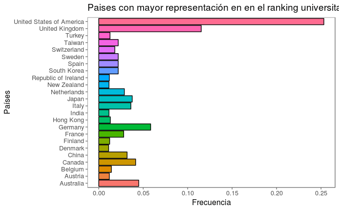

```r
tablaA <- as.matrix(tablaA)
tablaA <- data_frame(country=rownames(tablaA),freq=tablaA[,1])
tablaA %>% filter(freq>0.01) %>% arrange(desc(freq)) %>%
  ggplot(aes(country,freq,fill=country))+
  geom_col(col="black",show.legend = FALSE)+
  coord_flip()+
  theme_few()+
  ggtitle("Paises con mayor representación en en el ranking universitario")+
  xlab("Países")+
  ylab("Frecuencia")
```

## FUNCIONES

### Crear una funcion denominada rankUni que muestre n pantalla el nombre de la universidad al suministrale los argumentos world_rank y año de evaluación (year). La salida debe ser un vector caracter de longitud 1

```r
rankUni <- function(rank,year){
  require(dplyr)
  A <- worldUni %>%
    filter(world_rank==rank,year == year)
  as.character(A[1,2])
}
```

### Probando la función para los rangos

1,10 y 100 para los años 2015 y 2016 respectivamente

```r
rankUni(1,2015)
```

```
[1] "California Institute of Technology"
```

```r
rankUni(10,2015)
```

```
[1] "University of California, Berkeley"
```

```r
rankUni(100,2015)
```

```
[1] "University of York"
```

```r
rankUni(1,2016)
```

```
[1] "California Institute of Technology"
```

```r
rankUni(10,2016)
```

```
[1] "University of California, Berkeley"
```

```r
rankUni(100,2016)
```

```
[1] "University of York"
```

## Segunda Función

Un estudiante interesado en el puntaje de estas universidades quiere saber de manera inmediata si introduciendo un país aparecerán las universidades y sus rangos. Diseña una función denominada uniCountry que le de respuesta a este estudiante. Esta función usa como argumentos el país(country) y el año(usa por defecto el año 2016). En este caso la salida de la función debe ser una tabla que muestre las universidades de ese país y y su ranking mundial. Ten en cuenta que hay países que no están registrados en esta data frame y si lo introduces no se mostrara resultado alguno. Prueba tu función con Argentina, Chile, Colombia, México y Alemania.

```r
uniCountry <- function(pais,año=2016) {
  require(dplyr)
  worldUni %>%
    filter(country== pais & year== año) %>%
    arrange(world_rank) %>%
    select(university_name,world_rank)

}
```

Probemos la función Argentina, Chile, Colombia, México y Alemania.

```r
uniCountry("Argentina")
```

| university_name | world_rank |
| --- | --- |
| National University of Córdoba | 700 |

```r
uniCountry("Chile")
```

| university_name | world_rank |
| --- | --- |
| Federico Santa María Technical University | 450 |
| Pontifical Catholic University of Chile | 450 |
| University of Chile | 550 |
| Austral University of Chile | 700 |
| University of Santiago, Chile (USACH) | 700 |
| Pontifical Catholic University of Valparaíso | 700 |

```r
uniCountry("Mexico")
```

| university_name | world_rank |
| --- | --- |
| National Autonomous University of Mexico | 450 |
| Monterrey Institute of Technology and Higher Education | 550 |

```r
uniCountry("Colombia")
```

| university_name | world_rank |
| --- | --- |
| University of the Andes, Colombia | 550 |
| University of Antioquia | 700 |

```r
uniCountry("Germany")
```

| university_name | world_rank |
| --- | --- |
| LMU Munich | 29 |
| Heidelberg University | 37 |
| Humboldt University of Berlin | 49 |
| Technical University of Munich | 53 |
| Free University of Berlin | 72 |
| University of Tübingen | 78 |
| University of Freiburg | 84 |
| University of Bonn | 94 |
| University of Göttingen | 99 |
| University of Mannheim | 106 |

[output cut: 27 more lines]

### Crea una nueva variable categórica del ranking universitario utilizando tu propio criterio y representa gráficamente para los países americanos su distribución de frecuencia en el año 2016.

Para establecer cuales países estan en el continente americano utilizamos la informacion de gapminder y la unimos a nuestra dataframe con left_join de dplyr

```r
library(gapminder)
data("gapminder")
gap_2007 <- gapminder %>% filter(year == 2007)
unique(gap_2007$country)
```

```
  [1] Afghanistan              Albania
  [3] Algeria                  Angola
  [5] Argentina                Australia
  [7] Austria                  Bahrain
  [9] Bangladesh               Belgium
 [11] Benin                    Bolivia
 [13] Bosnia and Herzegovina   Botswana
 [15] Brazil                   Bulgaria
 [17] Burkina Faso             Burundi
 [19] Cambodia                 Cameroon
 [21] Canada                   Central African Republic
 [23] Chad                     Chile
 [25] China                    Colombia
 [27] Comoros                  Congo, Dem. Rep.
 [29] Congo, Rep.              Costa Rica
```

[output cut: 57 more lines]

```r
gap_2007 <- gap_2007 %>% mutate(country=as.character(country))
glimpse(gap_2007)
```

```
Observations: 142
Variables: 6
$ country   <chr> "Afghanistan", "Albania", "Algeria", "Angola", "Argentin...
$ continent <fctr> Asia, Europe, Africa, Africa, Americas, Oceania, Europe...
$ year      <int> 2007, 2007, 2007, 2007, 2007, 2007, 2007, 2007, 2007, 20...
$ lifeExp   <dbl> 43.828, 76.423, 72.301, 42.731, 75.320, 81.235, 79.829, ...
$ pop       <int> 31889923, 3600523, 33333216, 12420476, 40301927, 2043417...
$ gdpPercap <dbl> 974.5803, 5937.0295, 6223.3675, 4797.2313, 12779.3796, 3...
```

```r
unique(worldUni$country)
```

```
 [1] Iceland                   Taiwan
 [3] Thailand                  United States of America
 [5] United Kingdom            Turkey
 [7] United Arab Emirates      Chile
 [9] Greece                    New Zealand
[11] France                    Kenya
[13] Poland                    Colombia
[15] Italy                     Spain
[17] China                     Uganda
[19] Egypt                     Malaysia
[21] Australia                 Canada
[23] Ghana                     Czech Republic
[25] Argentina                 Republic of Ireland
[27] Romania                   Morocco
[29] Norway                    Estonia
```

[output cut: 22 more lines]

### El nombre United States of America en worldUni aparece como United States en gap_2007 se debe cambiar aplicando una función

```r
cambiarNombre <- function(n){
  ifelse(n=="United States", "United States of America",n)
}
```

Probemos la funcion

```r
cambiarNombre(c("United States","Colombia","Chile"))
```

```
[1] "United States of America" "Colombia"
[3] "Chile"
```

Apliquemos a gap_2007

```r
gap_2007 <- gap_2007 %>% mutate(country=cambiarNombre(country))
gap_2007 %>% filter(country=="United States of America")
```

| country | continent | year | lifeExp | pop | gdpPercap |
| --- | --- | --- | --- | --- | --- |
| United States of America | Americas | 2007 | 78.242 | 301139947 | 42951.65 |

### Hacer el left_join

```r
glimpse(gap_2007)
```

```
Observations: 142
Variables: 6
$ country   <chr> "Afghanistan", "Albania", "Algeria", "Angola", "Argentin...
$ continent <fctr> Asia, Europe, Africa, Africa, Americas, Oceania, Europe...
$ year      <int> 2007, 2007, 2007, 2007, 2007, 2007, 2007, 2007, 2007, 20...
$ lifeExp   <dbl> 43.828, 76.423, 72.301, 42.731, 75.320, 81.235, 79.829, ...
$ pop       <int> 31889923, 3600523, 33333216, 12420476, 40301927, 2043417...
$ gdpPercap <dbl> 974.5803, 5937.0295, 6223.3675, 4797.2313, 12779.3796, 3...
```

```r
worldUni <- left_join(gap_2007[1:2],worldUni,by="country")
```

```
Column `country` joining character vector and factor, coercing into character vector
```

```r
glimpse(worldUni)
```

```
Observations: 2,527
Variables: 15
$ country                <chr> "Afghanistan", "Albania", "Algeria", "Angol...
$ continent              <fctr> Asia, Europe, Africa, Africa, Americas, Oc...
$ world_rank             <int> NA, NA, NA, NA, 700, 375, 375, 326, 326, 32...
$ university_name        <chr> NA, NA, NA, NA, "National University of Cór...
$ teaching               <dbl> NA, NA, NA, NA, 16.0, 15.5, 15.7, 16.4, 16....
$ international          <dbl> NA, NA, NA, NA, 28.1, 64.6, 79.0, 46.7, 73....
$ research               <dbl> NA, NA, NA, NA, 9.0, 11.3, 16.2, 19.4, 18.7...
$ citations              <dbl> NA, NA, NA, NA, 12.5, 35.6, 20.3, 52.6, 54....
$ income                 <dbl> NA, NA, NA, NA, 28.6, 40.3, 30.7, 31.3, 31....
$ total_score            <dbl> NA, NA, NA, NA, NA, NA, NA, NA, NA, NA, NA,...
$ num_students           <dbl> NA, NA, NA, NA, 108373, 20314, 30251, 557, ...
$ student_staff_ratio    <dbl> NA, NA, NA, NA, 38.1, 36.5, 22.0, 25.4, 30....
$ international_students <dbl> NA, NA, NA, NA, 2, 33, 21, 15, 17, 43, 33, ...
$ year                   <int> NA, NA, NA, NA, 2016, 2012, 2012, 2012, 201...
$ female_male_ratio      <dbl> NA, NA, NA, NA, 1.6315789, 0.7857143, NA, 2...
```

```r
worldUni <- worldUni %>% mutate(country=factor(country))
```

### Creamos una variable categorica para los rangos

```r
worldUni <-  worldUni %>%
  mutate(univRanges=cut(world_rank,breaks=c(1,50,100,Inf),
                        labels=c("Alto","Intermedio","Bajo"),
                        include.lowest=TRUE))
worldUni %>% select(world_rank,univRanges,university_name)
```

| world_rank | univRanges | university_name |
| --- | --- | --- |
| NA | NA | NA |
| NA | NA | NA |
| NA | NA | NA |
| NA | NA | NA |
| 700 | Bajo | National University of Córdoba |
| 375 | Bajo | Swinburne University of Technology |
| 375 | Bajo | Griffith University |
| 326 | Bajo | Charles Darwin University |
| 326 | Bajo | Deakin University |
| 326 | Bajo | Murdoch University |

[output cut: 990 more lines]

## Distribucion de frecuencias para las universidades americanas

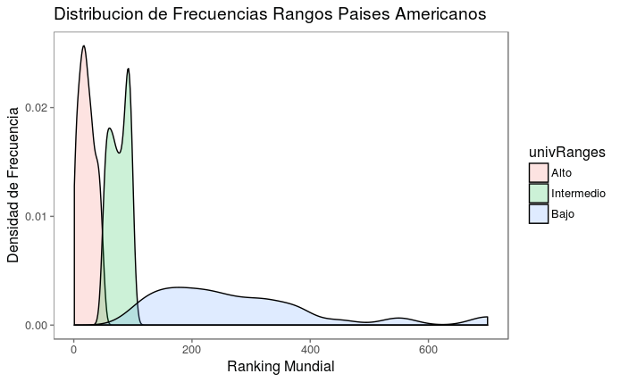

```r
worldUni %>%
  filter(continent=="Americas") %>%
  ggplot(aes(x=world_rank,fill=univRanges)) +
  geom_density(alpha=0.2) +
  theme_few()+
  ggtitle("Distribucion de Frecuencias Rangos Paises Americanos")+
  xlab("Ranking Mundial")+
  ylab("Densidad de Frecuencia")
```

## Representa gráficamente la variación anual del ranking universitario para las primeras 10 universidades

## evaluadas en este estudio

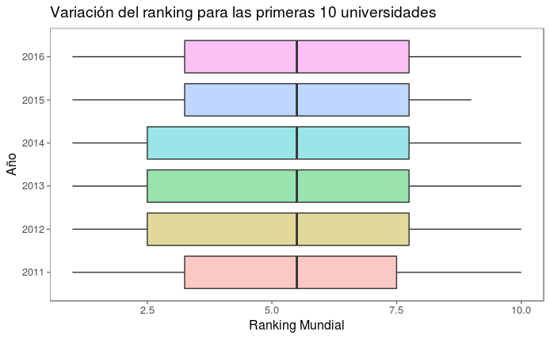

```r
worldUni %>%
  filter(world_rank <= 10) %>%
            ggplot(aes(year,world_rank,group=year,fill=factor(year)))+
  geom_boxplot(show.legend=FALSE,alpha=0.4)+
  ggtitle("Variación del ranking para las primeras 10 universidades")+
  ylab("Ranking Mundial")+
  xlab("Año")+
   scale_x_continuous( breaks = seq(2010, 2016, 1))+
  theme_few()+
  coord_flip()
```

### Elige un método(generación de data.frame, uso de gráficos) que te permita explorar las universidades

### con mayor proporción de estudiantes femeninas. ¿Tiene incidencia sobre el ranking evaluado?

```r
glimpse(worldUni)
```

```
Observations: 2,527
Variables: 16
$ country                <fctr> Afghanistan, Albania, Algeria, Angola, Arg...
$ continent              <fctr> Asia, Europe, Africa, Africa, Americas, Oc...
$ world_rank             <int> NA, NA, NA, NA, 700, 375, 375, 326, 326, 32...
$ university_name        <chr> NA, NA, NA, NA, "National University of Cór...
$ teaching               <dbl> NA, NA, NA, NA, 16.0, 15.5, 15.7, 16.4, 16....
$ international          <dbl> NA, NA, NA, NA, 28.1, 64.6, 79.0, 46.7, 73....
$ research               <dbl> NA, NA, NA, NA, 9.0, 11.3, 16.2, 19.4, 18.7...
$ citations              <dbl> NA, NA, NA, NA, 12.5, 35.6, 20.3, 52.6, 54....
$ income                 <dbl> NA, NA, NA, NA, 28.6, 40.3, 30.7, 31.3, 31....
$ total_score            <dbl> NA, NA, NA, NA, NA, NA, NA, NA, NA, NA, NA,...
$ num_students           <dbl> NA, NA, NA, NA, 108373, 20314, 30251, 557, ...
$ student_staff_ratio    <dbl> NA, NA, NA, NA, 38.1, 36.5, 22.0, 25.4, 30....
$ international_students <dbl> NA, NA, NA, NA, 2, 33, 21, 15, 17, 43, 33, ...
$ year                   <int> NA, NA, NA, NA, 2016, 2012, 2012, 2012, 201...
$ female_male_ratio      <dbl> NA, NA, NA, NA, 1.6315789, 0.7857143, NA, 2...
$ univRanges             <fctr> NA, NA, NA, NA, Bajo, Bajo, Bajo, Bajo, Ba...
```

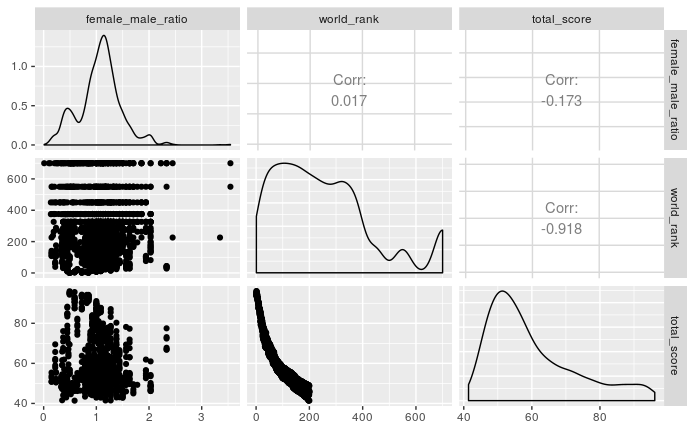

```r
ggpairs(worldUni[,c(15,3,10)])
```

En principio no hay una relacion clara entre enl ranking mundial y la proporcio de mujeres, sin embargo pueden hacerse análisis más detallados construyendo una variable categórica para la relaciona female_ratio; así por debajo de 1 se considera baja y por encima de 1 alto

```r
worldUni <- worldUni %>%
  mutate(femaleRatio=cut(female_male_ratio,breaks=c(0,1,Inf),labels=c("Bajo","Alto")))
```

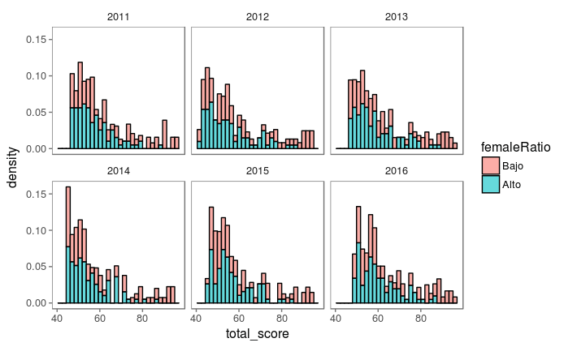

```r
worldUni %>% filter(!is.na(female_male_ratio)) %>%
  ggplot(aes(x=total_score,..density..,fill=femaleRatio))+
  geom_histogram(alpha=0.6,col="black")+
  facet_wrap(~year)+
  theme_few()
```

La figura muestra que se mantiene una baja proporción de mujeres en universidades en los años analizados sin variaciones importantes para aquellas universidades con un puntaje total por encima del 80%. # Animación

```
Removed 1204 rows containing non-finite values (stat_density).
```

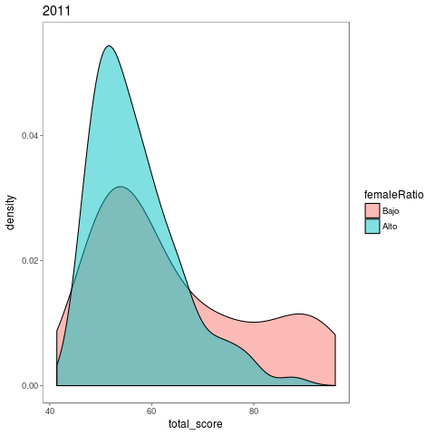

```r
p <- worldUni %>% filter(!is.na(female_male_ratio)) %>%
  ggplot(aes(x=total_score,fill=femaleRatio,frame=factor(year)))+
  geom_density(col="black",alpha=0.5)+
  theme_few()
gganimate(p)
```

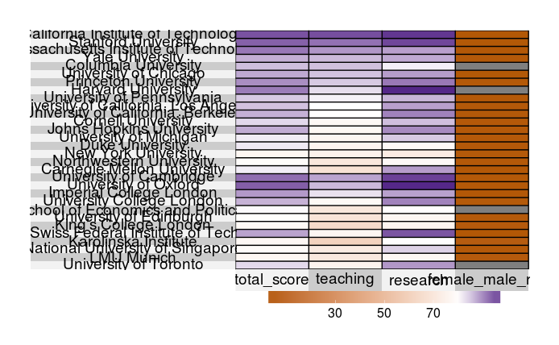

```r
library(superheat)
matrixA <- worldUni[,3:15]
matrix2016 <- matrixA %>% filter(world_rank<=30,year==2016)
matrix2016 <- as.data.frame(matrix2016)
rownames(matrix2016) <- matrix2016$university_name
matrix2016$university_name <- NULL
superheat(matrix2016[,c(7,2,4,12)],
          # change the size of the labels
          left.label.size = 0.7,row.title.size = 3,
          bottom.label.size = 0.09,heat.pal = c("#b35806", "white", "#542788"))
```

Como se ve, las intensidades en la relacion female:male son bajas para este grupode universidades

### ¿Existe una relación lineal importante entre las variables mostradas en este estudio. Usa gráficos o análisis de regresión que permitan justificar tu respuesta?

Este analisis lo podemos hacer en etapas: Exploar nubes de puntos de relaciones entre las variables Realizar estimaciones lineales con regresiones simples o múltiples

### Exploracion.

Análisis del conjunto de datos

```r
glimpse(worldUni)
```

```
Observations: 2,527
Variables: 17
$ country                <fctr> Afghanistan, Albania, Algeria, Angola, Arg...
$ continent              <fctr> Asia, Europe, Africa, Africa, Americas, Oc...
$ world_rank             <int> NA, NA, NA, NA, 700, 375, 375, 326, 326, 32...
$ university_name        <chr> NA, NA, NA, NA, "National University of Cór...
$ teaching               <dbl> NA, NA, NA, NA, 16.0, 15.5, 15.7, 16.4, 16....
$ international          <dbl> NA, NA, NA, NA, 28.1, 64.6, 79.0, 46.7, 73....
$ research               <dbl> NA, NA, NA, NA, 9.0, 11.3, 16.2, 19.4, 18.7...
$ citations              <dbl> NA, NA, NA, NA, 12.5, 35.6, 20.3, 52.6, 54....
$ income                 <dbl> NA, NA, NA, NA, 28.6, 40.3, 30.7, 31.3, 31....
$ total_score            <dbl> NA, NA, NA, NA, NA, NA, NA, NA, NA, NA, NA,...
$ num_students           <dbl> NA, NA, NA, NA, 108373, 20314, 30251, 557, ...
$ student_staff_ratio    <dbl> NA, NA, NA, NA, 38.1, 36.5, 22.0, 25.4, 30....
$ international_students <dbl> NA, NA, NA, NA, 2, 33, 21, 15, 17, 43, 33, ...
$ year                   <int> NA, NA, NA, NA, 2016, 2012, 2012, 2012, 201...
$ female_male_ratio      <dbl> NA, NA, NA, NA, 1.6315789, 0.7857143, NA, 2...
$ univRanges             <fctr> NA, NA, NA, NA, Bajo, Bajo, Bajo, Bajo, Ba...
$ femaleRatio            <fctr> NA, NA, NA, NA, Alto, Bajo, NA, Alto, Alto...
```

[output not shown]

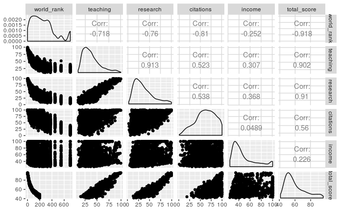

```r
worldUni %>%
  select(world_rank:total_score,-university_name,-num_students,-international) %>% ggpairs()
```

Vemos que hay correlaciones positivas importantes entre enseñanza(teaching);investigación(research)y numero de citas(citations). Esimportante destacar aqui el hecho de la relacion lineal negativa con world_rank, debemos recordar en la escala numerica 1 es el más alto, observos la fuerte correlacion entre total score y world_rank. En este sentido podemos escoger a total_score como una medida directa del world_rank y realizar un modelo de regression donde esta sea la variable dependiente

```r
modeloUniRanking <- lm(total_score ~ teaching + research + citations + income,data = worldUni)
summary(modeloUniRanking)
```

```
Call:
lm(formula = total_score ~ teaching + research + citations +
    income, data = worldUni)

Residuals:
     Min       1Q   Median       3Q      Max
-2.99592 -1.13653 -0.03767  1.22082  3.01806

Coefficients:
            Estimate Std. Error t value Pr(>|t|)
(Intercept) 4.173632   0.278723   14.97   <2e-16 ***
teaching    0.261875   0.006147   42.60   <2e-16 ***
research    0.330682   0.005340   61.92   <2e-16 ***
citations   0.309318   0.003165   97.74   <2e-16 ***
income      0.025861   0.002181   11.86   <2e-16 ***
---
Signif. codes:  0 ‘***’ 0.001 ‘**’ 0.01 ‘*’ 0.05 ‘.’ 0.1 ‘ ’ 1

Residual standard error: 1.446 on 998 degrees of freedom
  (1524 observations deleted due to missingness)
Multiple R-squared:  0.9874,    Adjusted R-squared:  0.9874
F-statistic: 1.962e+04 on 4 and 998 DF,  p-value: < 2.2e-16
```

En nuestro caso una regresion multiple es mas adecuada e indica el peso de cada componente sobre el puntaje universitario(dado por la pendiente); fijemonos que la pendiente para ingresos tiene una menor contribución sobre el modelo. Otras técnicas pueden ser implementadas pero escapan de los objetivos del curso; por ejemplo machine learning con arboles de regresion o clasificacion con reglas de asociación.

Evaluemos graficamente: Recordemos que modeloUniRanking es n objeto tipo lista que contiene amplia informacion sobre los parametros del modelo de regresion 1. se agrega la ccolumna de prediccion del modelo 2. se genera el intervalo de confianza

```r
modeloUniRanking <- lm(total_score ~ teaching + research + citations + income,
                       data = worldUni)
worldUni$model <- stats::predict(modeloUniRanking, newdata=worldUni)
err <- stats::predict(modeloUniRanking, newdata=worldUni, se = TRUE)
glimpse(worldUni)
```

```
Observations: 2,527
Variables: 18
$ country                <fctr> Afghanistan, Albania, Algeria, Angola, Arg...
$ continent              <fctr> Asia, Europe, Africa, Africa, Americas, Oc...
$ world_rank             <int> NA, NA, NA, NA, 700, 375, 375, 326, 326, 32...
$ university_name        <chr> NA, NA, NA, NA, "National University of Cór...
$ teaching               <dbl> NA, NA, NA, NA, 16.0, 15.5, 15.7, 16.4, 16....
$ international          <dbl> NA, NA, NA, NA, 28.1, 64.6, 79.0, 46.7, 73....
$ research               <dbl> NA, NA, NA, NA, 9.0, 11.3, 16.2, 19.4, 18.7...
$ citations              <dbl> NA, NA, NA, NA, 12.5, 35.6, 20.3, 52.6, 54....
$ income                 <dbl> NA, NA, NA, NA, 28.6, 40.3, 30.7, 31.3, 31....
$ total_score            <dbl> NA, NA, NA, NA, NA, NA, NA, NA, NA, NA, NA,...
$ num_students           <dbl> NA, NA, NA, NA, 108373, 20314, 30251, 557, ...
$ student_staff_ratio    <dbl> NA, NA, NA, NA, 38.1, 36.5, 22.0, 25.4, 30....
$ international_students <dbl> NA, NA, NA, NA, 2, 33, 21, 15, 17, 43, 33, ...
$ year                   <int> NA, NA, NA, NA, 2016, 2012, 2012, 2012, 201...
$ female_male_ratio      <dbl> NA, NA, NA, NA, 1.6315789, 0.7857143, NA, 2...
$ univRanges             <fctr> NA, NA, NA, NA, Bajo, Bajo, Bajo, Bajo, Ba...
$ femaleRatio            <fctr> NA, NA, NA, NA, Alto, Bajo, NA, Alto, Alto...
$ model                  <dbl> NA, NA, NA, NA, 15.94589, 24.02335, 20.7152...
```

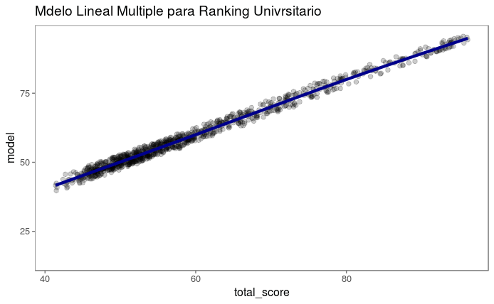

```r
g <- ggplot(worldUni)
g <- g + geom_point(aes(x=total_score ,y = model), size = 2, colour = "black",alpha=0.2)
g <- g + geom_smooth(data=worldUni, aes(x=total_score, y=model), size = 1.5,
            colour = "Darkblue", se = TRUE, stat = "smooth")
g + theme_few() + ggtitle("Mdelo Lineal Multiple para Ranking Univrsitario")
```

### El modelo se puede evaluar como un objeto tidy y graficar

### el efecto de cada variable predictiva sobre el puntaje total

```r
library(broom)
tidyModel <- tidy(modeloUniRanking)
tidyModel
```

| term | estimate | std.error | statistic | p.value |
| --- | --- | --- | --- | --- |
| (Intercept) | 4.17363188 | 0.278723267 | 14.97411 | 7.022627e-46 |
| teaching | 0.26187543 | 0.006147461 | 42.59896 | 8.973768e-227 |
| research | 0.33068240 | 0.005340252 | 61.92262 | 0.000000e+00 |
| citations | 0.30931848 | 0.003164839 | 97.73593 | 0.000000e+00 |
| income | 0.02586105 | 0.002181400 | 11.85525 | 1.997554e-30 |

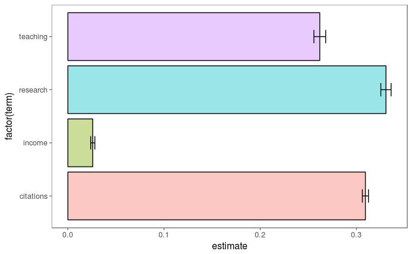

```r
tidyModel %>% filter(term != "(Intercept)") %>%
  ggplot(aes(x=factor(term),y=estimate, fill=term))+
  geom_col(alpha=0.4,show.legend = F,col="black")+
  theme_few()+
  geom_errorbar(aes(ymin=estimate-std.error,ymax=estimate+std.error),
                width = 0.25)+
  coord_flip()
```

## Evaluación del Ranking Universitario por Continente

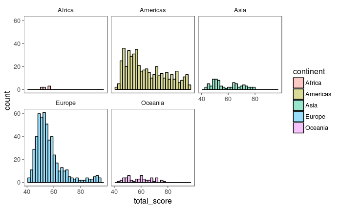

```r
p <- worldUni %>% ggplot(aes(x=total_score, fill=continent))+geom_histogram(alpha=0.4,col="black")+
  facet_wrap(~continent)+
  theme_few()
p
```